# NEON forecast challenge submission

2024-03-21

```r
install.packages("tidymodels")
install.packages("ranger")
library(tidymodels)
library(ranger)
tidymodels_prefer()
set.seed(100) #for random number generation
```

```r
knitr::opts_chunk$set(echo = TRUE)
```

```r
library(tidyverse)
library(lubridate)
```

# Obtain data

```r
#read in the targets data
targets <- read_csv('https://data.ecoforecast.org/neon4cast-targets/aquatics/aquatics-targets.csv.gz')
# read in the sites data
aquatic_sites <- read_csv("https://raw.githubusercontent.com/eco4cast/neon4cast-targets/main/NEON_Field_Site_Metadata_20220412.csv") |>
  dplyr::filter(aquatics == 1)
lake_sites <- aquatic_sites %>%
  filter(field_site_subtype == 'Lake')

# Filter the targets
targets <- targets %>%
  filter(site_id %in% lake_sites$field_site_id,
         variable == 'temperature')
```

```r
# past stacked weather
df_past <- neon4cast::noaa_stage3()

variables <- c("air_temperature", "relative_humidity",  "eastward_wind", "air_pressure", "surface_downwelling_longwave_flux_in_air", "surface_downwelling_shortwave_flux_in_air") # add some other variables
#Other variable names can be found at https://projects.ecoforecast.org/neon4cast-docs/Shared-Forecast-Drivers.html#stage-3

noaa_past <- df_past  |>
  dplyr::filter(site_id %in% lake_sites$field_site_id,
                datetime >= ymd('2017-01-01'),
                variable %in% variables) |>
  dplyr::collect()
```

```r
# aggregate the past to mean values
noaa_past_mean <- noaa_past |>
  mutate(datetime = as_date(datetime)) |>
  group_by(datetime, site_id, variable) |>
  summarize(prediction = mean(prediction, na.rm = TRUE), .groups = "drop") |>
  pivot_wider(names_from = variable, values_from = prediction) |>
  # convert air temp to C
  mutate(air_temperature = air_temperature - 273.15)
```

```r
forecast_date <- Sys.Date()
noaa_date <- forecast_date - lubridate::days(2)

df_future <- neon4cast::noaa_stage2(start_date = as.character(noaa_date))

variables <- c("air_temperature", "relative_humidity", "eastward_wind", "air_pressure", "surface_downwelling_longwave_flux_in_air", "surface_downwelling_shortwave_flux_in_air")

noaa_future <- df_future |>
  dplyr::filter(datetime >= forecast_date,
                site_id %in% lake_sites$field_site_id,
                variable %in% variables) |>
  collect()
```

```r
noaa_future_daily <- noaa_future |>
  mutate(datetime = as_date(datetime)) |>
  # mean daily forecasts at each site per ensemble
  summarize(prediction = mean(prediction), .by = c("datetime", "site_id", "parameter", "variable")) |>
  pivot_wider(names_from = variable, values_from = prediction) |>
  # convert to Celsius
  mutate(air_temperature = air_temperature - 273.15) |>
  select(datetime, site_id, air_temperature,relative_humidity, eastward_wind, air_pressure, surface_downwelling_longwave_flux_in_air, surface_downwelling_shortwave_flux_in_air, parameter)
```

```r
targets_df <- targets |>
  filter(variable == 'temperature') |>
  pivot_wider(names_from = 'variable', values_from = 'observation') |>
  left_join(noaa_past_mean,
            by = c("datetime","site_id")) |>
  mutate(doy = yday(datetime))


#Remove all the NA.obs
clean_data = na.omit(targets_df)

# use the correlation matrix to see which predictors are highly correlated with each other and with our response variable (temperature). We want strong correlation between response and regressors, and no or weak correlation between predictirs.
correlation_matrix <- cor(clean_data[, c("air_temperature", "relative_humidity", "eastward_wind", "air_pressure", "surface_downwelling_longwave_flux_in_air", "surface_downwelling_shortwave_flux_in_air" ,"temperature")], use = "complete.obs")

correlation_matrix= as.data.frame(correlation_matrix)

#temp is highly correlated with air_temp(89%), followed by surface_longwave(79%), air_pressure(57%) and surface_shortwave(50%). Also, air_temp and surface are highly correlated(86%). I decided to keep the predictors which are correlated with each other less than 50%. therefore surface_long to omit.

clean_data = clean_data %>% select(c(1:5,9,10))
```

# Pre processing

```r
split <- initial_split(clean_data, prop = 0.80, strata = site_id)
split
```

```
## <Training/Testing/Total>
## <3849/965/4814>
```

```r
train_data <- training(split)
test_data <- testing(split)
summary(test_data)
```

```
##     datetime            site_id           temperature     air_pressure
##  Min.   :2020-09-24   Length:965         Min.   : 1.51   Min.   : 87763
##  1st Qu.:2021-08-17   Class :character   1st Qu.:15.97   1st Qu.: 95250
##  Median :2022-07-23   Mode  :character   Median :20.58   Median : 96308
##  Mean   :2022-07-01                      Mean   :20.14   Mean   : 97937
##  3rd Qu.:2023-05-19                      3rd Qu.:24.57   3rd Qu.:101370
##  Max.   :2024-03-14                      Max.   :31.96   Max.   :102616
##  air_temperature  surface_downwelling_shortwave_flux_in_air      doy
##  Min.   :-4.206   Min.   :  0.0                             Min.   :  3.0
##  1st Qu.:13.016   1st Qu.:147.0                             1st Qu.:135.0
##  Median :18.307   Median :214.2                             Median :200.0
##  Mean   :17.467   Mean   :204.6                             Mean   :193.2
##  3rd Qu.:22.697   3rd Qu.:265.7                             3rd Qu.:266.0
##  Max.   :30.189   Max.   :357.9                             Max.   :365.0
```

# Split training data into folds

To tune the hyperparameters of the model, we will divide the training data into “folds”.

We will randomly create 10 different folds because a single fold may not be representative of the full training set and the size of the assessment set within a fold is relatively small.

```r
folds <- vfold_cv(train_data, v = 10)
folds
```

```
## #  10-fold cross-validation
## # A tibble: 10 × 2
##    splits             id
##    <list>             <chr>
##  1 <split [3464/385]> Fold01
##  2 <split [3464/385]> Fold02
##  3 <split [3464/385]> Fold03
##  4 <split [3464/385]> Fold04
##  5 <split [3464/385]> Fold05
##  6 <split [3464/385]> Fold06
##  7 <split [3464/385]> Fold07
##  8 <split [3464/385]> Fold08
##  9 <split [3464/385]> Fold09
## 10 <split [3465/384]> Fold10
```

# Feature engineering using a recipe

```r
forecast_recipe <- clean_data |>
  recipe(temperature ~ . ) |>
  step_rm(datetime) |>
  step_naomit(air_temperature,air_pressure, surface_downwelling_shortwave_flux_in_air,temperature)
```

## Step 3: Specify model and workflow

### Model

i will use random forest model. I will tune two of them in our model (`mtry` and `min_n`). Setting the hyper-parameter equal to `tune()` is a placeholder that says we plan to tune it. We also set `num.threads = parallel::detectCores()` so that the tuning uses the power of your computer to the fullest.

```r
rand_for_model <-
  rand_forest(mtry = tune(), min_n = tune(), trees = 1000) %>%
  set_engine("ranger", num.threads = parallel::detectCores()) |>
  set_mode("regression")
```

# Workflow

```r
forecast_wflow <-
  workflow() |>
  add_model(rand_for_model) |>
  add_recipe(forecast_recipe)
```

## Train model

- all data is divided into training and testing sets.
- The training set has 10 different grouping of training data. Each group has an analysis and assessment set.

# Estimate best hyper-parameters using tuning

The `tune_grid()` function will train the model+recipe defined in the workflow using a set of parameters on a subset of the training data (analysis set). It then calculates a metric that describes how well the model with that set of hyper-parameter predicts the the “assessment” set.

We will be using the metric root-mean-squeared error to measure how good the model fit is (`metrics = metric_set(rmse)`)

`control = control_grid(save_pred = TRUE)` just says to save the predictions for each fold.

```r
forecast_resample_fit <-
  forecast_wflow |>
  tune_grid(resamples = folds,
            grid = 25,
            control = control_grid(save_pred = TRUE),
            metrics = metric_set(rmse))
```

In total the random forest model was run 25 * 10 times (25 different hyperparameter sets x 10 different folds of the training data).

In the table below that is sorted so that best hyperparameter set (lowest RMSE) is at the top. You can see the value for `mtry` and `min_n` that were used in the training and mean RMSE (`mean`) across all 10 “folds” (`n` is the number of folds).

```r
forecast_resample_fit %>%
  collect_metrics() |>
  arrange(mean)
```

```
## # A tibble: 25 × 8
##     mtry min_n .metric .estimator  mean     n std_err .config
##    <int> <int> <chr>   <chr>      <dbl> <int>   <dbl> <chr>
##  1     2     3 rmse    standard    1.16    10  0.0184 Preprocessor1_Model05
##  2     4     5 rmse    standard    1.18    10  0.0222 Preprocessor1_Model09
##  3     4     7 rmse    standard    1.20    10  0.0203 Preprocessor1_Model15
##  4     5     4 rmse    standard    1.20    10  0.0236 Preprocessor1_Model17
##  5     2     8 rmse    standard    1.20    10  0.0188 Preprocessor1_Model04
##  6     4    10 rmse    standard    1.22    10  0.0208 Preprocessor1_Model24
##  7     2    15 rmse    standard    1.27    10  0.0188 Preprocessor1_Model21
##  8     4    16 rmse    standard    1.28    10  0.0222 Preprocessor1_Model22
##  9     2    19 rmse    standard    1.30    10  0.0180 Preprocessor1_Model19
## 10     4    19 rmse    standard    1.30    10  0.0212 Preprocessor1_Model18
## # ℹ 15 more rows
```

```r
#extract the hyperparameters with the best metric (`rmse`)
best_hyperparameters <- forecast_resample_fit %>%
  select_best("rmse")
```

## Update workflow with best hyper-parameters

Our workflow (model + recipe) needs to know the hyper-parameters to use to fit the model. The `finalize_workflow` function updates the workflow to contain the best hyper-parameters.

```r
final_workflow <-
  forecast_wflow %>%
  finalize_workflow(best_hyperparameters)
```

# Fit to all training data

We use the same approach as we have used before to train the model using the **full** training data (does not use the 10 folds).

```r
forecast_fit <- final_workflow |>
  fit(data = train_data)
```

```r
predictions <- predict(forecast_fit, new_data = test_data)
```

```r
pred_test <- bind_cols(test_data, predictions)
```

# Model evaluation

```r
multi_metric <- metric_set(rmse, rsq)

metric_table <- pred_test |>
  multi_metric(truth = temperature, estimate = .pred)
```

#Model evaluation scatter plot

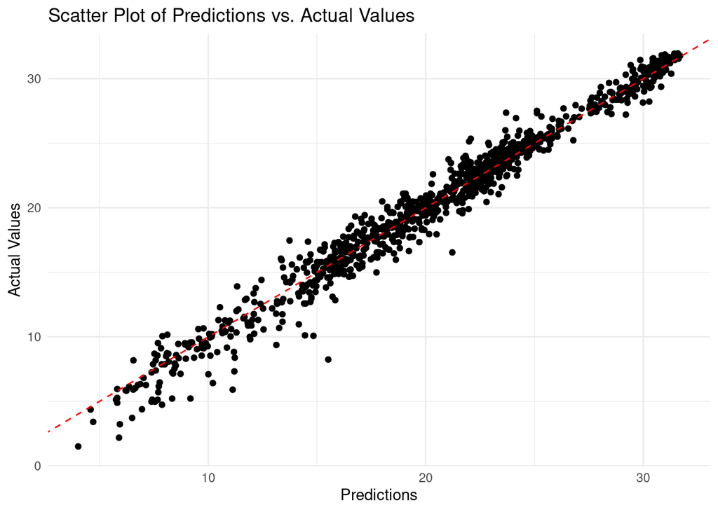

```r
library(ggplot2)

# Extract predictions and actual values
predictions <- pred_test$.pred
actual_values <- pred_test$temperature

# Create a scatter plot
ggplot(data = data.frame(predictions, actual_values), aes(x = predictions, y = actual_values)) +
  geom_point() +
  geom_abline(intercept = 0, slope = 1, linetype = "dashed", color = "red") +
  labs(title = "Scatter Plot of Predictions vs. Actual Values",
       x = "Predictions",
       y = "Actual Values") +
  theme_minimal()
```

This scatter plot helps visualize how well model’s predictions align with the actual temperature values. The dashed red line represents a perfect prediction, and points close to this line indicate accurate predictions. From the plot we can observe that most of the points are close to the red line indicating the accurate prediction.

# deploy model

Ensemble (or sample) forecast: Ensemble (or sample) forecasts use the family value of ensemble and the parameter values are the ensemble index.

```r
#residual for each ensemble member
resid = pred_test$.pred - pred_test$temperature

#Create sigma for process unt
sigma = sd(resid, na.rm = TRUE)

targets_future <- noaa_future_daily |>
  mutate(temperature = NA,
         doy = yday(datetime))

tidymodels_forecast <- data.frame()

for(i in unique(targets_future$parameter)){
  curr_ens <- targets_future |>
    filter(parameter == i) |>
    select(-parameter)

  new_predictions <- predict(forecast_fit, new_data = curr_ens)
  #adding process uncertainty to each ensemble members
  new_predictions$.pred = new_predictions$.pred + rnorm(n=length(new_predictions$.pred),mean=0,sd=sigma)
  curr_ens <- bind_cols(curr_ens, new_predictions) |>
    mutate(parameter = i)
  tidymodels_forecast <- bind_rows(tidymodels_forecast, curr_ens)
}
```

```r
tidymodels_forecasts_EFI <- tidymodels_forecast %>%
  rename(prediction = .pred) %>%
  mutate(variable = "temperature") |>
  # For the EFI challenge we only want the forecast for future
  filter(datetime > Sys.Date()) %>%
  group_by(site_id, variable) %>%
  mutate(reference_datetime = min(datetime) - lubridate::days(1),
         family = "ensemble",
         model_id = "RF_tidyModel") %>%
  select(model_id, datetime, reference_datetime, site_id, family, parameter, variable, prediction)
```

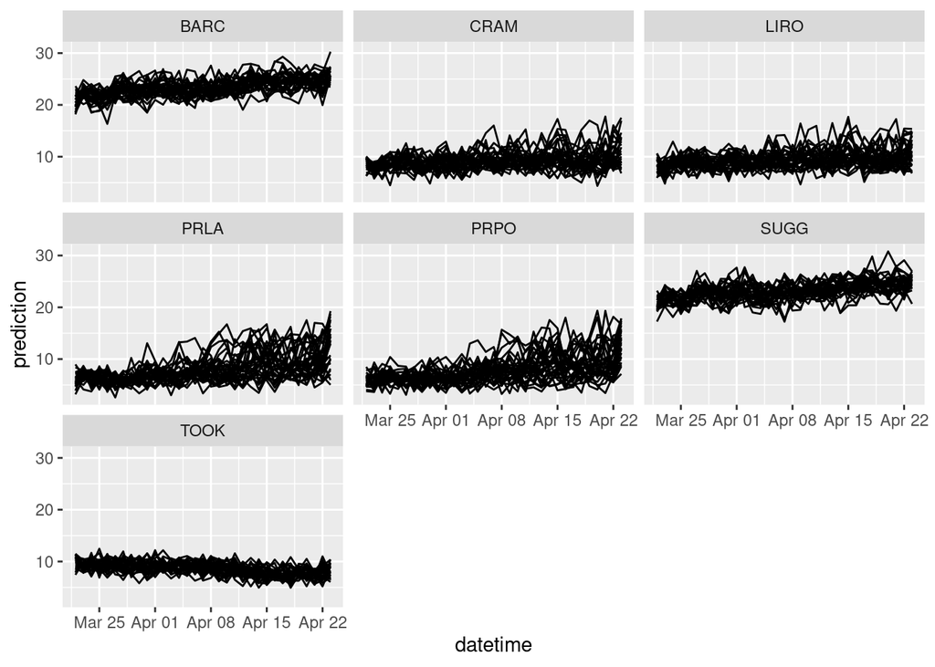

```r
tidymodels_forecasts_EFI |>
  filter(variable == "temperature") |>
  ggplot(aes(x = datetime, y = prediction, group = parameter)) +
  geom_line() +
  facet_wrap(~site_id)
```

# Convert to EFI Standard for submission

```r
my_model_id <- 'Sujan_forecast'

tidymodels_forecasts_EFI <- tidymodels_forecast %>%
  filter(datetime > forecast_date) %>%
  mutate(model_id = my_model_id,
         reference_datetime = forecast_date,
         family = 'ensemble',
         variable = "temperature",
         prediction = .pred,
         parameter = as.character(parameter)) %>%
  select(datetime, reference_datetime, site_id, family, parameter, variable, prediction, model_id)
```

```r
# Write the forecast to file
theme <- 'aquatics'
date <- tidymodels_forecasts_EFI$reference_datetime[1]
forecast_name_1 <- paste0(tidymodels_forecasts_EFI$model_id[1], ".csv")
forecast_file_1 <- paste(theme, date, forecast_name_1, sep = '-')
forecast_file_1
```

```
## [1] "aquatics-2024-03-21-Sujan_forecast.csv"
```

```r
if (!dir.exists('Forecasts')) {
  dir.create('Forecasts')
}

write_csv(tidymodels_forecasts_EFI, file.path('Forecasts',forecast_file_1))
```

Check that forecast format is valid

```r
neon4cast::forecast_output_validator(file.path('Forecasts',forecast_file_1))
```

```
## Forecasts/aquatics-2024-03-21-Sujan_forecast.csv
```

```
## ✔ file has model_id column
## ✔ forecasted variables found correct variable + prediction column
## ✔ file has correct family and parameter columns
## ✔ file has site_id column
## ✔ file has datetime column
## ✔ file has correct datetime column
```

```
## ✔ file has reference_datetime column
## Forecast format is valid
```

```
## [1] TRUE
```

```r
neon4cast::submit(forecast_file = file.path('Forecasts', forecast_file_1), ask = FALSE) # if ask = T (default), it will produce a pop-up box asking if you want to submit
```

```
## validating that file matches required standard
```

```
## Forecasts/aquatics-2024-03-21-Sujan_forecast.csv
```

```
## ✔ file has model_id column
## ✔ forecasted variables found correct variable + prediction column
## ✔ file has correct family and parameter columns
## ✔ file has site_id column
## ✔ file has datetime column
## ✔ file has correct datetime column
```

```
## ✔ file has reference_datetime column
## Forecast format is valid
##
## Thank you for submitting!
```

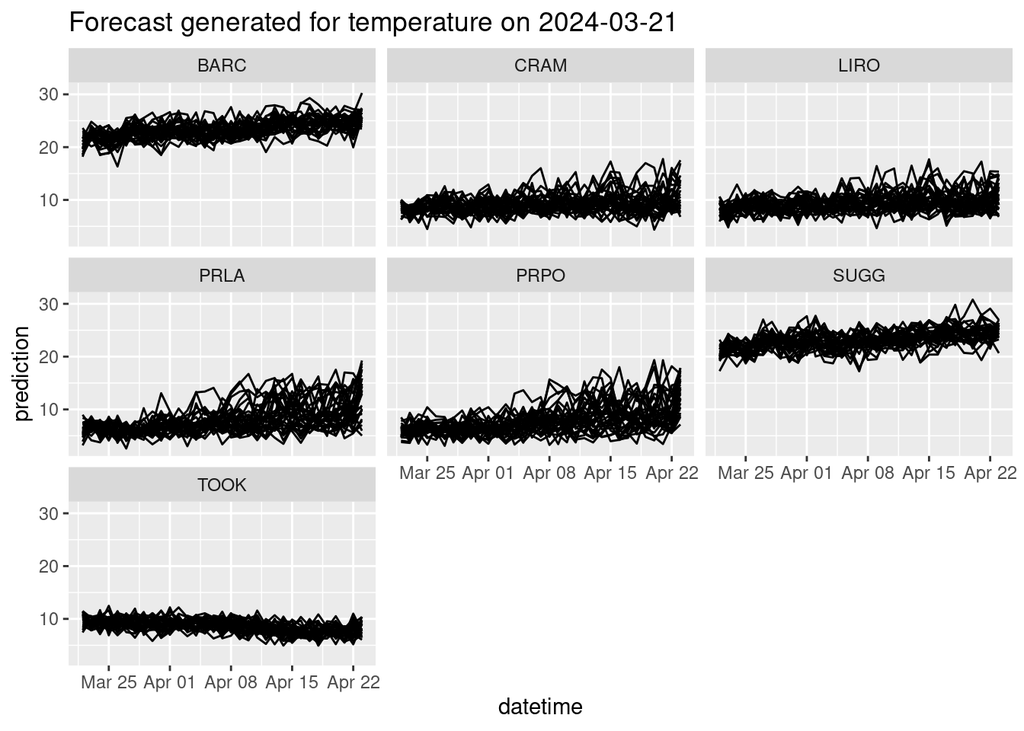

```r
tidymodels_forecasts_EFI |>
  ggplot(aes(x=datetime, y=prediction, group = parameter)) +
  geom_line() +
  facet_wrap(~site_id) +
  labs(title = paste0('Forecast generated for ', tidymodels_forecasts_EFI$variable[1], ' on ', tidymodels_forecasts_EFI$reference_datetime[1]))
```